# Practical Machine Learning Project

YonasTH

November 5, 2016

## Introduction

Using devices such as Jawbone Up, Nike FuelBand, and Fitbit it is now possible to collect a large amount of data about personal activity relatively inexpensively. These type of devices are part of the quantified self movement-a group of enthusiasts who take measurements about themselves regularly to improve their health, to find patterns in their behavior, or because they are tech geeks. One thing that people regularly do is quantify how much of a particular activity they do, but they rarely quantify how well they do it. In this project, your goal will be to use data from accelerometers on the belt, forearm, arm, and dumbell of 6 participants. They were asked to perform barbell lifts correctly and incorrectly in 5 different ways. More information is available from the website here: http://groupware.les.inf.puc-rio.br/har (see the section on the Weight Lifting Exercise Dataset).

## Project Objective

Six young health participants were asked to perform one set of 10 repetitions of the Unilateral Dumbbell Biceps Curl in five different fashions:  
- exactly according to the specification (Class A)  
- throwing the elbows to the front (Class B)  
- lifting the dumbbell only halfway (Class C)  
- lowering the dumbbell only halfway (Class D)  
- throwing the hips to the front (Class E)  
The goal of this project is to predict the manner in which they did the exercise and these are contained in the *classe* variabe.

## Load Data

```r
library(caret)
training <- read.csv("~/Practical Machine Learning/Course_project/pml-training.csv")
testing <- read.csv("~/Practical Machine Learning/Course_project/pml-testing.csv")
```

## Exploratory Data Analysis

```r
length(names(training))
```

```
## [1] 160
```

There are 160 variables in the training dataset, the last of which is the *classe* variable.

```r
#check if there are missing values
sum(is.na(training))
```

[1] 1287472 There are a number of NA values that need to be handled. Variables containing NAs may be omitted from the prediction or values can be imputed using the nearest neighbor method.  
The last columns in the training and testing data are *Classe* and *problem_id*, respectively.Excluding the last columns, verify that all column names in the training and testing datasets are identical.

```r
colnames_train <- colnames(training)
colnames_test <- colnames(testing)
all.equal(colnames_train[1:length(colnames_train)-1], colnames_test[1:length(colnames_test)-1])
```

[1] TRUE

## Preprocessing

The testing set contains only 20 observations while the training set contains 19622 observations. The training set is partitioned into training and testing sets for cross-validation.The final selected model will then be applied on the testing set of 20 observations.

```r
inTrain <- createDataPartition(training$classe, p=0.7, list=FALSE)
raw_training_cv <- training[inTrain, ]
raw_testing_cv <- training[-inTrain,]

#remove covariates with near-zero-variablity
nzv <- nearZeroVar(raw_training_cv, saveMetrics=TRUE)
raw_training_cv <- raw_training_cv[ , nzv$nzv==FALSE]
raw_testing_cv <- raw_testing_cv[ ,nzv$nzv==FALSE]

#Keep only variables without NAs
training_cv <- raw_training_cv[ , colSums(is.na(raw_training_cv))==0]
#remove the first six columns of raw_training_cv, which are row numbers and time series info; the data analysis has no time-dependence
training_cv <- training_cv[c(-1,-2,-3,-4,-5,-6)]
length(colnames(training_cv))
```

[output not shown]

The **training_cv** data now contain 53 variables.Transform **testing_cv** and **testing** datasets so that they contain only variables in **training_cv**.

```r
testing_cv <- raw_testing_cv[ , colnames(training_cv)] #same colnames as training_cv
testing <- testing[ , colnames(training_cv[ ,-53])]#same as training_cv w/o last column
```

## Training and Prediction with Decision Trees

```r
library(randomForest)
library(rattle)
library(rpart.plot)
```

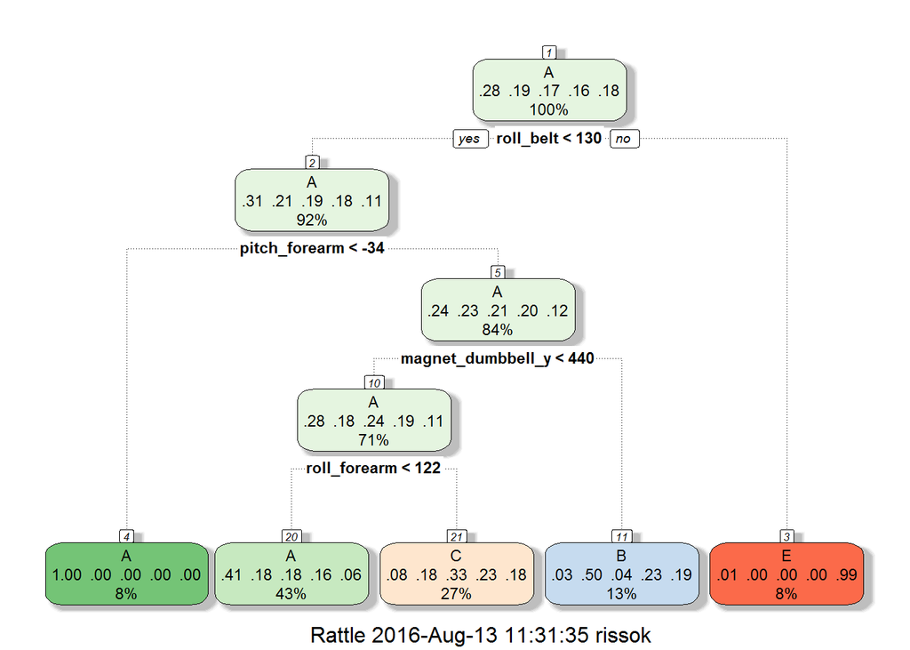

```r
set.seed(12345)
Fit_trees <- train(classe~., data = training_cv, method="rpart")
fancyRpartPlot(Fit_trees$finalModel)
```

```r
Prediction_trees <- predict(Fit_trees, testing_cv)
conf_mat <- confusionMatrix(Prediction_trees, testing_cv$classe )
conf_mat
```

```
## Confusion Matrix and Statistics
##
##           Reference
## Prediction    A    B    C    D    E
##          A 1516  476  480  458  152
##          B   27  400   38  158  147
##          C  130  263  508  348  296
##          D    0    0    0    0    0
##          E    1    0    0    0  487
##
## Overall Statistics
##
##                Accuracy : 0.4946
##                  95% CI : (0.4818, 0.5075)
##     No Information Rate : 0.2845
##     P-Value [Acc > NIR] : < 2.2e-16
##
##                   Kappa : 0.3391
##  Mcnemar's Test P-Value : NA
##
## Statistics by Class:
##
##                      Class: A Class: B Class: C Class: D Class: E
## Sensitivity            0.9056  0.35119  0.49513   0.0000  0.45009
## Specificity            0.6281  0.92204  0.78658   1.0000  0.99979
## Pos Pred Value         0.4919  0.51948  0.32880      NaN  0.99795
## Neg Pred Value         0.9436  0.85552  0.88065   0.8362  0.88975
## Prevalence             0.2845  0.19354  0.17434   0.1638  0.18386
## Detection Rate         0.2576  0.06797  0.08632   0.0000  0.08275
## Detection Prevalence   0.5237  0.13084  0.26253   0.0000  0.08292
## Balanced Accuracy      0.7669  0.63661  0.64085   0.5000  0.72494
```

The **accuracy** is very low (0.49) and the **out of sample error** is 0.51.

## Training and Prediciton with Random Forests

```r
library(randomForest)
```

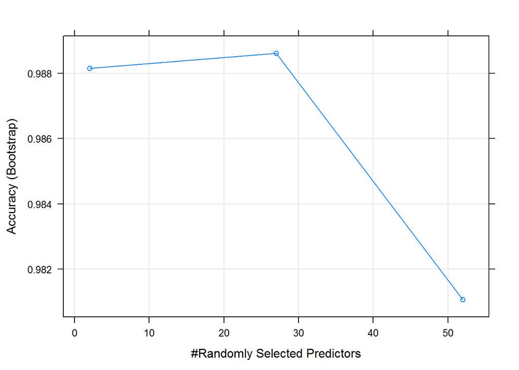

```r
set.seed(12345)
Fit_rf <- train(classe~., data = training_cv, method = "rf")
plot(Fit_rf)
```

```r
Prediction_rf <- predict(Fit_rf, testing_cv)
conf_mat2 <- confusionMatrix(Prediction_rf, testing_cv$classe)
conf_mat2
```

```
## Confusion Matrix and Statistics
##
##           Reference
## Prediction    A    B    C    D    E
##          A 1672   11    0    0    0
##          B    0 1128    5    2    0
##          C    1    0 1019   14    1
##          D    0    0    2  947    0
##          E    1    0    0    1 1081
##
## Overall Statistics
##
##                Accuracy : 0.9935
##                  95% CI : (0.9911, 0.9954)
##     No Information Rate : 0.2845
##     P-Value [Acc > NIR] : < 2.2e-16
##
##                   Kappa : 0.9918
##  Mcnemar's Test P-Value : NA
##
## Statistics by Class:
##
##                      Class: A Class: B Class: C Class: D Class: E
## Sensitivity            0.9988   0.9903   0.9932   0.9824   0.9991
## Specificity            0.9974   0.9985   0.9967   0.9996   0.9996
## Pos Pred Value         0.9935   0.9938   0.9845   0.9979   0.9982
## Neg Pred Value         0.9995   0.9977   0.9986   0.9966   0.9998
## Prevalence             0.2845   0.1935   0.1743   0.1638   0.1839
## Detection Rate         0.2841   0.1917   0.1732   0.1609   0.1837
## Detection Prevalence   0.2860   0.1929   0.1759   0.1613   0.1840
## Balanced Accuracy      0.9981   0.9944   0.9949   0.9910   0.9993
```

The **accuracy** of the random forest method is very high (0.99). **Out of sample error** is, therefore, 0.01. Save the result **Fit_rf** object for later use, say in reporting.

```r
save(Fit_rf, file="Fit_rf.RData")
```

The first five variables of high importance in the model are reported as follows together with their relative importance index:

```r
Var_imp <- varImp(Fit_rf)$importance
Var_imp[head(order(Var_imp, decreasing=TRUE), 5L), , drop=FALSE]
```

```
##                     Overall
## roll_belt         100.00000
## pitch_forearm      61.67263
## yaw_belt           55.30631
## pitch_belt         45.32550
## magnet_dumbbell_y  44.34917
```

## Prediction on the 20-sample Test Set

The 20 samples are classified into the following classes by using the randomForest model developed.

```r
#load the saved training model result object
load(file = "Fit_rf.RData", verbose = TRUE)
```

```
## Loading objects:
##   Fit_rf
```

```r
prediction_onTEST <- predict(Fit_rf, testing)
prediction_onTEST
```

```
##  [1] B A B A A E D B A A B C B A E E A B B B
## Levels: A B C D E
```